# Fast Growth Companies Prediction Model

Yuri Almeida Cunha

2021-02-11

## INTRODUCTION

The idea of the following report is to provide statistical models capable of predicting whether a company will perform as “fast_growth” or not in the future. This allows us to decide where to invest or not to invest our precious money.

## THE DATASET

The dataset is compounded by the business results and some characteristics of a few companies in a specific country during the period of 2012-2014. The variable used to determine whether the company was a fast growth enterprise during the period, Compound Annual Growth Rate (CAGR), was based in the their annual sales results.

The CAGR is the estimated growth rate calculated for a certain amount of years, in our case, the growth of the sales under 2012-14. i.e CAGR = (Sales_2014/Sales_2012) ^ (1/2) - 1

WIth that in our hands, we could determine **fast_growth companies** as the companies where the **CAGR** were superior than its general mean distribution and the **absolute difference** in sales from 2012 to 2014 bigger than its own 3rd quartile.

On the graph bellow, you can visualize the distribution of fast_growth companies:

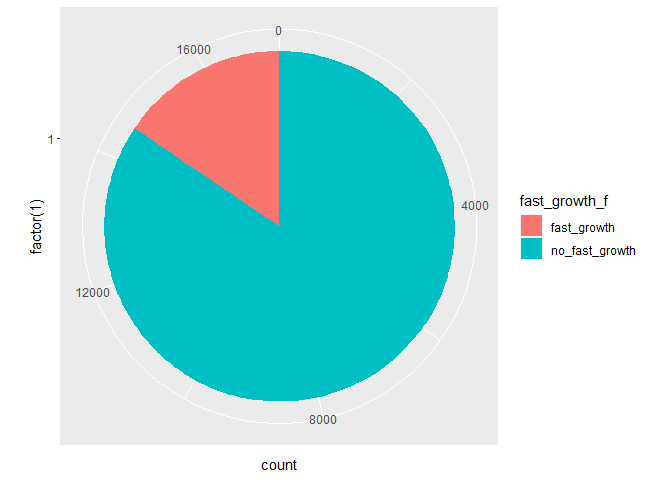

## THE PREDICTION

Using the business result variables (i.e assets, profit, etc.) and other factor ones (i.e. ceo_numbers, origin, etc.),the data of the year 2012 was selected to be used as the prediction set. It’s important to mention that the models were originally inspired on the ones executed in our class “ch17-predicting-firm-exit”, please check the following repo for more information: https://github.com/gabors-data-analysis/da_case_studies

The main difference from the prediction analysis applied was the addition of flags on changes over the factor values from 2012 to 2014, those were called “extra_changed” in the code. This addition was an attempt to improve the predictions of the model highlighting if there were a change on one of those factors during the period we established our CAGR. With that, we could better track either if these modifications were important part of the fast growth prediction or not.

## LOGIT

Once we defined the methodology and variables to create our models it’s time to run the logit ones.

The table bellow shows the results achieved with the models X1 to X6 and the Lasso ones. As already mentioned above, the analysis follows the same structure of the exercise in class, however this time the models X6 and LASSO_EXTRA also include the flags on the factor changes.

It’s important to mention through the analysis of the table that the best model, considering the lower RMSE, is the LASSO one. This decision could also be done considering the AUC value, however focusing on the main goal of the models (reduce expected loss), the RMSE is better interpretable and correspond more to the real expected loss.

The second important topic important to describe goes back to our changed factors. Although they showed themselves significant to prediction on the LASSO_EXTRA model, they increased the RMSE, not being at this time the best model to be used as prediction. This could have been caused due to some multi-colinearity or very few samples of changes.

|  | Number.of.predictors | CV.RMSE | CV.AUC |
| --- | --- | --- | --- |
| **X1** | 4 | 0.3622 | 0.5763 |
| **X2** | 11 | 0.3568 | 0.6481 |
| **X3** | 24 | 0.3537 | 0.6676 |
| **X4** | 67 | 0.3529 | 0.6708 |
| **X5** | 79 | 0.3528 | 0.6705 |
| **X6** | 88 | 0.3528 | 0.6703 |
| **LASSO** | 61 | 0.3522 | 0.6499 |
| **LASSO_EXTRA** | 76 | 0.3524 | 0.6504 |

## BEST MODEL THRESHOLD ANALYSIS , CONSUSION MATRIX AND LOSS FUNCTION

with the best model selected, it’s time to analyze the ROC curve. The ROC curve is a graphical plot that illustrates the diagnostic ability of a binary classifier system as its discrimination threshold is varied. On another way of saying that, it defines the threshold trade-off associated with the possibility of committing False Positive Errors(FP) or False Negative Errors (FN).

The LASSO ROC curve can be visualized bellow as an example:

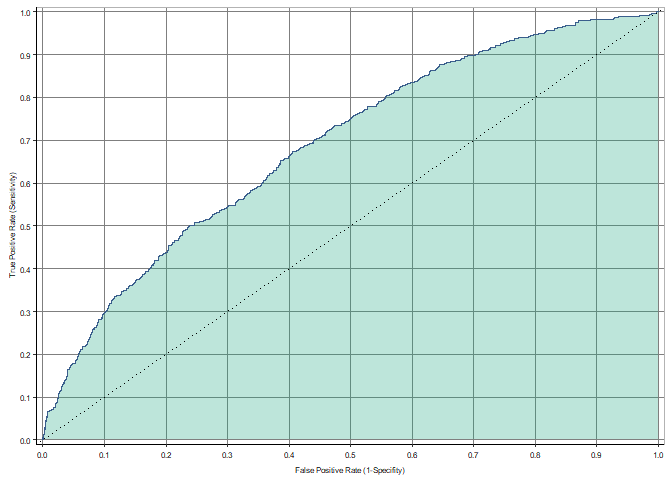

Now that we can generate the ROC curve for all the models, and with that, the trade-off probability of committing FPs and FNs, we should create a loss function to determine what would be the best threshold to be used in every model case. Considering our business scenario is obvious that the money investment should be done in our considered fast growth companies. So, it’s clear that the biggest loss in this case would be achieving a great amount of FP cases (investing a lot of money into corporations that wouldn’t grown that much, instead of losing market opportunity by not investing in a good one).

The table bellow consolidates all the optimal thresholds for which one of the models and their average expected loss in which model:

|  | Avg.of.optimal.thresholds | Avg.expected.loss |
| --- | --- | --- |
| **X1** | 0.155 | 0.9501 |
| **X2** | 0.165 | 0.9162 |
| **X3** | 0.1582 | 0.8993 |
| **X4** | 0.1498 | 0.8805 |
| **X5** | 0.1574 | 0.8976 |
| **X6** | 0.1575 | 0.9019 |
| **LASSO** | 0.1603 | 0.9824 |
| **LASSO_EXTRA** | 0.1604 | 0.9649 |

Different from what we chose on the beginning, now the best for prediction is the X4 because it leads us to the best Avg.Expected.Loss between all models. For cases of Classification the RMSE isn’t a good choice of a loss function. Instead of summarizing the differences into distribution probabilities of the event occurring or not, our actual loss function check the difference between the true factor outcome and it’s value predicted. That makes possible to the generate a expected loss number to each model.

## RANDOW FOREST PREDICTION AND FINAL SUMMARY

Finally, we reached the moment to run the Random Forest prediction models (RFs). Athough the RF models require much more time to train and much more computer power because it generates a lot of trees and makes decision on the majority of votes, it’s still very stable algorithm. Considering that amount of trees, it’s less impacted by noise, reduces the overfitting and variance improving the accuracy.

The table bellow contain the overview of all models:

|  | Number.of.predictors | CV.RMSE | CV.AUC | CV.threshold | CV.expected.Loss |
| --- | --- | --- | --- | --- | --- |
| **X1** | 4 | 0.3622 | 0.5763 | 0.155 | 0.9501 |
| **X2** | 11 | 0.3568 | 0.6481 | 0.165 | 0.9162 |
| **X3** | 24 | 0.3537 | 0.6676 | 0.1582 | 0.8993 |
| **X4** | 67 | 0.3529 | 0.6708 | 0.1498 | 0.8805 |
| **X5** | 79 | 0.3528 | 0.6705 | 0.1574 | 0.8976 |
| **X6** | 88 | 0.3528 | 0.6703 | 0.1575 | 0.9019 |
| **LASSO** | 61 | 0.3522 | 0.6499 | 0.1603 | 0.9824 |
| **LASSO_EXTRA** | 76 | 0.3524 | 0.6504 | 0.1604 | 0.9649 |
| **rf_p** | 35 | 0.3503 | 0.6944 | 0.01357 | 0.8215 |
| **rf_p_extra** | 44 | 0.3496 | 0.6965 | 0.01361 | 0.823 |

The RF model showed itself the best one (lower expected loss value) as our goal in this project is to predict better what are the fast growth companies. The casualty and impact evaluation between the explanatory and dependent variable can be left behind this case, but it’s interesting to mention that the addition of the flags of the changes into factor values from 2012 to 2014 showed statistically significant, however not relevant for a model decision.

## CONCLUSION

The models created to predict the fast growth companies proved to be significant, however requires a lot of improvement in terms of accuracy.

The models are still better than simply random choice, however the prediction capabilities are really low. It’s necessary to re-take and analyze back all feature engineering process defining better variables for prediction. Although they can offer some data insights, none of them can’t be used in real business life.